# R Notebook

# Intro

This notebook plays around with some visualisation of the total weight/volume of the rubbish for the streets with bin sensors.

Load in the clean data:

```r
library(tidyverse)
library(sf)

#read in the cleaned and combined bin & osm data
combined_bin_osm <- st_read(here::here("cleaned_data/combined_bin_osm_data/combined_bin_osm.shp"), quiet = TRUE)

#undoing some shortened naming when read to shape file
combined_bin_osm <- combined_bin_osm %>%
  rename("street_name" = "strt_nm",
        "total_vol_l3" = "ttl_v_3",
       "total_weight_kg" = "ttl_wg_",
       "cumul_total_vol_l3" = "cm_t__3",
       "cumul_total_weight_kg" = "cm_tt__",
       "highway_group" = "hghwy_g")

# read in all the .shp files in the cleaned osm data folder
root <- here::here()
dir_path <- paste0(root, '/cleaned_data/osm_data/')
file_pattern <- '*.shp'
shp_files <- list.files(dir_path, pattern = file_pattern)


for (i in seq_along(shp_files)) {
  assign(str_remove(shp_files[i], ".shp"), st_read(paste0(dir_path, shp_files[i]),  quiet = TRUE))
}

#undoing some shortened naming when read to shape file
streets_simplified <- streets_simplified %>%
  rename("street_name" = "strt_nm",
         "highway_group" = "hghwy_g")

# setting the max and min lat/long for cropping visual
min_max_coords <- c(ymin= 55.928479867725436,
                    xmin= -3.227624857214751,
                    ymax= 55.98333902701634,
                    xmax= -3.140735628435386)

# ------------------------------------------------------------------------------

# subset the data so only the last bin collection date (so get 1 row per street)
last_date <- combined_bin_osm %>%
  st_drop_geometry() %>% #no need for geometry
  summarise(min_date = max(date))%>%
  pull()

last_date_bin_collection_sf <- combined_bin_osm %>%
  filter(date == last_date)
```

# Visualsing spatially the total rubbish weight per street

Setting up the ‘base’ spatial plot of Edinburgh city centre using the OSM data. The line thickness denotes the type of street/road. The wider the thickness the more ‘major’ the street/road is (either small/medium/large).

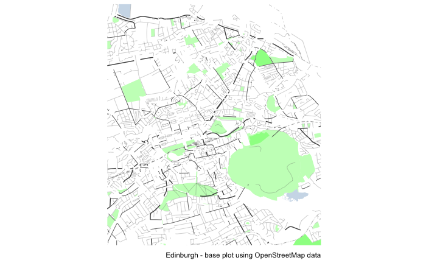

```r
# Plots -------------------------------------

map_theme <-theme(axis.line=element_blank(),
                axis.text.x=element_blank(),
                axis.text.y=element_blank(),
                axis.ticks=element_blank(),
                axis.title.x=element_blank(),
                axis.title.y=element_blank(),
                plot.background=element_blank(),
                panel.grid.minor=element_blank(),
                panel.background=element_blank(),
                panel.grid.major=element_blank())

base_plot <- ggplot() +
  map_theme +
  geom_sf(data = water,
          fill = "steelblue",
          # size = .8,
          lwd = 0,
          alpha = .3) +
  geom_sf(data = park_multipoly,
          fill = "green",
          # size = .8,
          lwd = 0,
          alpha = .3) +
  geom_sf(data = park_poly,
          fill = "green",
          # size = .8,
          lwd = 0,
          alpha = .3) +
  geom_sf(data = railways,
          color = "grey30",
          size = .2,
          linetype="dotdash",
          alpha = .5) +
  geom_sf(data = filter(streets_simplified, highway_group == "small"),
          size = .1,
          color = "grey40") +
  geom_sf(data = filter(streets_simplified, highway_group == "medium"),
          size = .3,
          color = "grey35") +
  geom_sf(data = filter(streets_simplified, highway_group == "large"),
          size = .5,
          color = "grey30") +
    coord_sf(ylim = c(min_max_coords[1], min_max_coords[3]),
           xlim = c(min_max_coords[2], min_max_coords[4]),
           expand = FALSE)

base_plot +
   labs(caption = 'Edinburgh - base plot using OpenStreetMap data', size = 2)
```

Now playing around with different ways to visualise the data:

Highlighting which streets have sensor bins on:

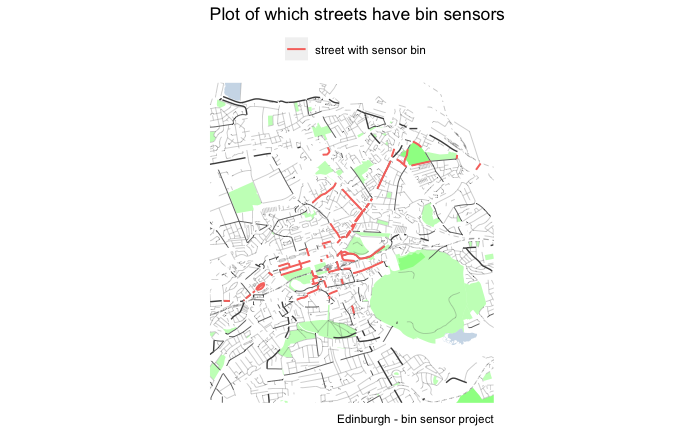

```r
# Highlighting which streets have sensor bins on ----------------------------
# to have in README

base_plot +
  geom_sf(data =  last_date_bin_collection_sf, aes(color = "street with sensor bin"), size = .7, show.legend = "line") +
  labs(caption = 'Edinburgh - bin sensor project', title= "Plot of which streets have bin sensors", size = 2) +
  coord_sf(ylim = c(min_max_coords[1], min_max_coords[3]),
           xlim = c(min_max_coords[2], min_max_coords[4]),
           expand = FALSE) +
  theme(legend.position = "top", legend.title = element_blank())
```

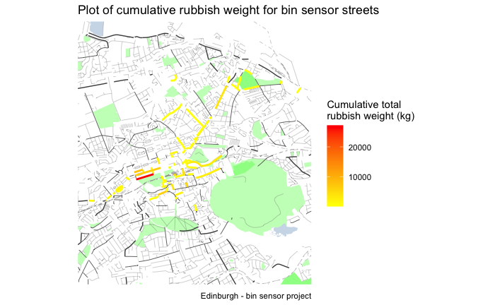

```r
# Last bin collection colour showing weight ----------------------------
base_plot +
  geom_sf(data =  last_date_bin_collection_sf, aes(colour = cumul_total_weight_kg),
          size = 1,
          show.legend = "line") +
  scale_colour_gradient(low = "yellow", high = "red", name = "Cumulative total \nrubbish weight (kg)") +
  labs(caption = 'Edinburgh - bin sensor project', title = "Plot of cumulative rubbish weight for bin sensor streets", size = 2) +
  coord_sf(ylim = c(min_max_coords[1], min_max_coords[3]),
           xlim = c(min_max_coords[2], min_max_coords[4]),
           expand = FALSE)
```

Princes Street is a bit of an outlier here so hard to see the differences between the other streets.

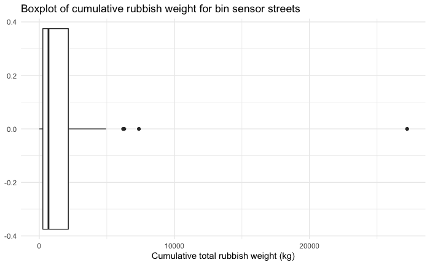

```r
last_date_bin_collection_sf %>%
  ggplot(aes(cumul_total_weight_kg)) +
  geom_boxplot() +
  xlab("Cumulative total rubbish weight (kg)") +
  ggtitle("Boxplot of cumulative rubbish weight for bin sensor streets") +
  theme_minimal()
```

Yes Princes Street is a big outlier. Makes sense as it is the main shopping street in Edinburgh and lots of footfall. In future look to see if any open footfall data to add to analysis.

Could do a transformation of the variable to show the differences between the other streets more, or show some plot without Princes Street (which have below).

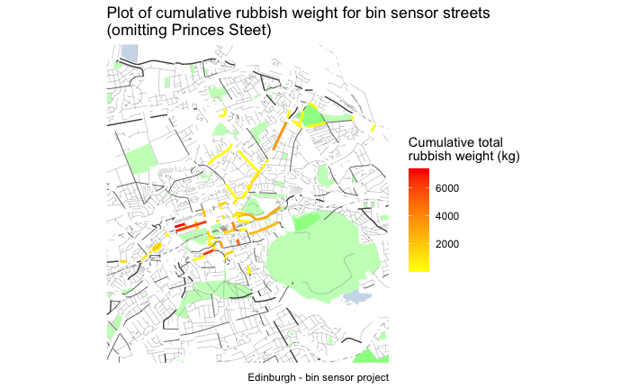

```r
# Last bin collection colour showing weight removing Princes Street as is  ----------------------------
base_plot +
  geom_sf(data =  filter(last_date_bin_collection_sf, street_name != "princes street"), aes(colour = cumul_total_weight_kg),
          size = 1,
          show.legend = "line") +
  scale_colour_gradient(low = "yellow", high = "red", name = "Cumulative total \nrubbish weight (kg)") +
  labs(caption = 'Edinburgh - bin sensor project', title = "Plot of cumulative rubbish weight for bin sensor streets\n(omitting Princes Steet)", size = 2) +
  coord_sf(ylim = c(min_max_coords[1], min_max_coords[3]),
           xlim = c(min_max_coords[2], min_max_coords[4]),
           expand = FALSE)
```

Play around with using the using the weight of the street to denote the weight:

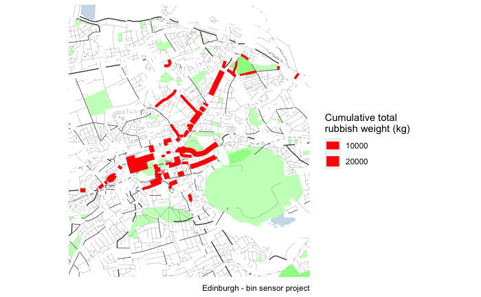

```r
# Last bin collection thickness showing weight ----------------------------
# decided against this way to visualise as not very clear
base_plot +
  geom_sf(data =  last_date_bin_collection_sf, aes(size = cumul_total_weight_kg),
          show.legend = "line", colour = "red") +
  labs(caption = 'Edinburgh - bin sensor project', size = "Cumulative total \nrubbish weight (kg)") +
  coord_sf(ylim = c(min_max_coords[1], min_max_coords[3]),
           xlim = c(min_max_coords[2], min_max_coords[4]),
           expand = FALSE)
```

Don’t think this is a good way of visualising this data!

# Visalising the cumulative rubbish on each street over time

Now going to look at how the weight changes over time:

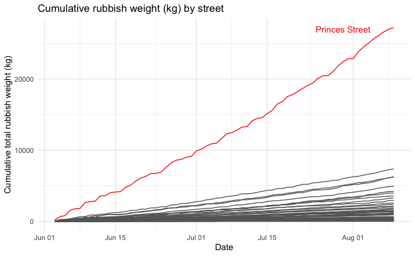

```r
# Streets over time ----------------------------
combined_bin_osm %>%
  ggplot(aes(x = date, y = cumul_total_weight_kg, group = street_name, colour = street_name == "princes street")) +
  geom_line() +
  scale_colour_manual(values = c("grey40", "red"), guide = "none") +
  annotate("text", x=as.Date("2016-07-30"), y=27000, label="Princes Street", color = "red") +
  theme_minimal() +
  labs(x = "Date", y = "Cumulative total rubbish weight (kg)", title = "Cumulative rubbish weight (kg) by street")
```

Again, Princes Street dominates the chart here but it has a steady rate of change. Going to look more at the rate of change for each of the streets by visualising the log transformations.

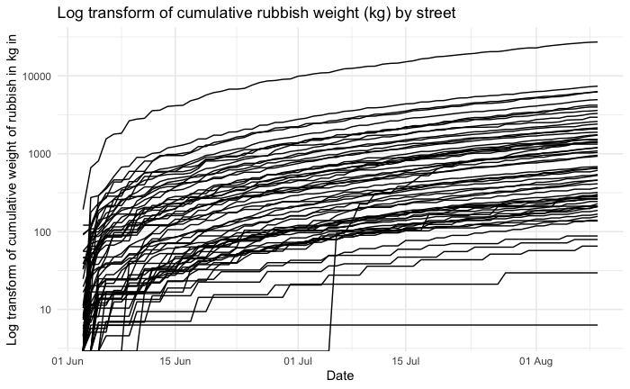

```r
#transform to a log axis on y to compare rate of change
combined_bin_osm %>%
  ggplot(aes(x = date, y = cumul_total_weight_kg, group = street_name)) +
  geom_line() +
  scale_y_continuous(trans = "log10") +
  scale_x_date(date_labels = "%d %b") +
   theme_minimal() +
  labs(y = "Log transform of cumulative weight of rubbish in kg in" , x = "Date", title = "Log transform of cumulative rubbish weight (kg) by street")
```

Seems to be a common pattern for most of the streets in the rate of change. Pinpointed 2 locations, Calton Hill and Hermitage Place that seem to have a bit of a different pattern to look at in isolation:

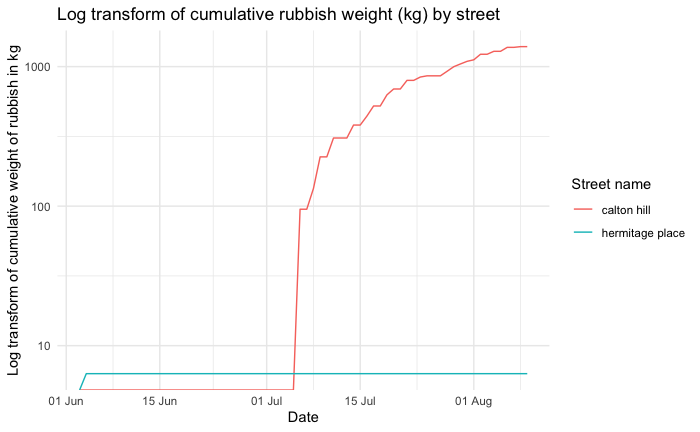

```r
combined_bin_osm %>%
  filter(street_name %in% c("calton hill", "hermitage place")) %>%
  ggplot(aes(x = date, y = cumul_total_weight_kg, color = street_name)) +
  geom_line() +
  scale_y_continuous(trans ="log10") +
  scale_x_date(date_labels = "%d %b") +
  labs(y = "Log transform of cumulative weight of rubbish in kg", x = "Date", title = "Log transform of cumulative rubbish weight (kg) by street", colour = "Street name") +
  theme_minimal()
```

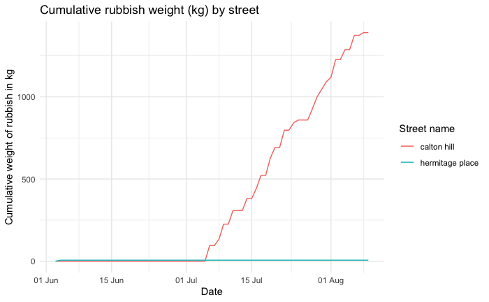

```r
combined_bin_osm %>%
  filter(street_name %in% c("calton hill", "hermitage place")) %>%
  ggplot(aes(x = date, y = cumul_total_weight_kg, color = street_name)) +
  scale_x_date(date_labels = "%d %b") +
  labs(y = "Cumulative weight of rubbish in kg", x = "Date", title = "Cumulative rubbish weight (kg) by street", colour = "Street name") +
  geom_line() +
  theme_minimal()
```

Either there was no rubbish on Hermitage Place (it is a little out of city centre) or the sensor perhaps didn’t work. Similarly for Calton Hill perhaps there was an issue with the sensor as after the start of July the rate of increase increases sharply.